# How does early-stage funding affect the long-term success or failure of startups?

- Show All Code
- Hide All Code
- View Source

Data Analysis Project

Author

Joshua Wong

## Introduction

As you’ve heard in the news and social media, startups are becoming increasingly popular in public interest. According to [Forbes](https://www.forbes.com/advisor/business/what-is-a-startup/), a startup is defined as “a businesses that wants to disrupt industries and change the world—and do it all at scale.” Oftentimes, it’s high-risk high-reward, especially the earlier you are in it. This crucial early stage shapes the outcome of the business, and to keep it alive with high-growth, many founders raise rounds to fund their company. This paper aims to analyze the impact of early-stage funding on the longer-term success (or failure) of startups. For this research question, we will define “early-stage funding” as a startup that’s raised an angel investment and/or a series A investment. For more information about startup rounds, you may find some useful information [here](https://www.forbes.com/sites/alejandrocremades/2018/12/26/how-funding-rounds-work-for-startups/?sh=49cbfb767386). The “success” of a startup will be defined in two separate ways: if the startup was in the “Top 500” startups (according to the data) and if the startup was acquired. As defined, please note that both success metrics will have their own respective analyses and findings, and correlation between the success metrics will not be performed in the scope of this article.

### Data Description

The dataset used in this analysis, [startup-data.csv](https://www.kaggle.com/datasets/manishkc06/startup-success-prediction/data), includes comprehensive information regarding various startups including their funding history and current status. This dataset has data about different funding rounds as well as geographical information, average number of funding participants, and the current status of each startup (e.g., acquired, closed). The dataset provides a snapshot of 923 startups betweeen 1984 and 2013.

### Objective

The objective of this data analysis is to examine the relationship between early-stage funding and the long-term success of startups. A key hypothesis is that startups receiving early-stage funding have a higher likelihood of long-term success compared to those without. This analysis aims to validate / challenge this hypothesis through some data exploration and statistical testing of the dataset.

### Approach

- Identify and categorize startups based on their early-stage funding status (VC, angel investment, and Round A funding).
- Analyze the correlation between early-stage funding and the long-term success or failure of these startups.
- Perform statistical tests to ascertain the strength and significance of these correlations.
- Use visualizations to illustrate key findings and trends in the data.

# Setup

### Packages

```r
# Load necessary packages
library(tidyverse)
library(dplyr)
library(ggplot2)
library(readr)
library(here)
library(lubridate)
library(DT)
library(scales)
```

### Load Data

```r
startup_data <- read_csv(here("data/startup-data.csv"))
```

### Interactive Preview of Cleaned Data

The original dataset underwent several cleaning processes:

- Conversion of relevant columns to appropriate data types.
- Categorization of startups based on their funding status (VC, angel investment, and Round A, etc.).
- Filtering to focus on critical attributes like funding status, geographic location, and current status.

```r
# Remove unnecessary columns
startup_data <- startup_data |>
  select(-c('Unnamed: 0', 'Unnamed: 6'))

# Convert data types
startup_data <- startup_data |>
  mutate(
    latitude = as.numeric(latitude),
    longitude = as.numeric(longitude),
    zip_code = as.character(zip_code),
    founded_at = mdy(founded_at),
    closed_at = mdy(closed_at),
    first_funding_at = mdy(first_funding_at),
    last_funding_at = mdy(last_funding_at),
    across(starts_with('age'), as.numeric),
    funding_total_usd = as.numeric(funding_total_usd),
    avg_participants = as.numeric(avg_participants),
    across(contains('is_'), as.logical),
    status = as.factor(status)
  )

# Drop NA for status column
startup_data <- startup_data |>
  drop_na(status)

# Create a new column 'early_stage_funding' to indicate if a startup has received any early-stage funding
startup_data <- startup_data |>
  mutate(early_stage_funding = has_angel | has_roundA)
```

## Interactive Preview of Cleaned Data

```r
datatable(startup_data, options = list(pageLength = 5, scrollX = TRUE))
```

|  | state_code | latitude | longitude | zip_code | id | city | name | labels | founded_at | closed_at | first_funding_at | last_funding_at | age_first_funding_year | age_last_funding_year | age_first_milestone_year | age_last_milestone_year | relationships | funding_rounds | funding_total_usd | milestones | state_code.1 | is_CA | is_NY | is_MA | is_TX | is_otherstate | category_code | is_software | is_web | … |
| --- | --- | --- | --- | --- | --- | --- | --- | --- | --- | --- | --- | --- | --- | --- | --- | --- | --- | --- | --- | --- | --- | --- | --- | --- | --- | --- | --- | --- | --- | --- |
| 1 | CA | 42.35888 | -71.05682 | 92101 | c:6669 | San Diego | Bandsintown | 1 | 2007-01-01 |  | 2009-04-01 | 2010-01-01 | 2.2493 | 3.0027 | 4.6685 | 6.7041 | 3 | 3 | 375000 | 3 | CA | True | False | False | False | False | music | False | False | … |
| 2 | CA | 37.238916 | -121.973718 | 95032 | c:16283 | Los Gatos | TriCipher | 1 | 2000-01-01 |  | 2005-02-14 | 2009-12-28 | 5.126 | 9.9973 | 7.0055 | 7.0055 | 9 | 4 | 40100000 | 1 | CA | True | False | False | False | False | enterprise | False | False | … |
| 3 | CA | 32.901049 | -117.192656 | 92121 | c:65620 | San Diego | Plixi | 1 | 2009-03-18 |  | 2010-03-30 | 2010-03-30 | 1.0329 | 1.0329 | 1.4575 | 2.2055 | 5 | 1 | 2600000 | 2 | CA | True | False | False | False | False | web | False | True | … |
| 4 | CA | 37.320309 | -122.05004 | 95014 | c:42668 | Cupertino | Solidcore Systems | 1 | 2002-01-01 |  | 2005-02-17 | 2007-04-25 | 3.1315 | 5.3151 | 6.0027 | 6.0027 | 5 | 3 | 40000000 | 1 | CA | True | False | False | False | False | software | True | False | … |
| 5 | CA | 37.779281 | -122.419236 | 94105 | c:65806 | San Francisco | Inhale Digital | 0 | 2010-08-01 | 2012-10-01 | 2010-08-01 | 2012-04-01 | 0 | 1.6685 | 0.0384 | 0.0384 | 2 | 2 | 1300000 | 1 | CA | True | False | False | False | False | games_video | False | False | … |
| 6 | CA | 37.406914 | -122.09037 | 94043 | c:22898 | Mountain View | Matisse Networks | 0 | 2002-01-01 | 2009-02-15 | 2006-07-18 | 2006-07-18 | 4.5452 | 4.5452 | 5.0027 | 5.0027 | 3 | 1 | 7500000 | 1 | CA | True | False | False | False | False | network_hosting | False | False | … |
| 7 | CA | 37.3915589 | -122.0702643 | 94041 | c:16191 | Mountain View | RingCube Technologies | 1 | 2005-01-01 |  | 2006-09-21 | 2010-03-18 | 1.7205 | 5.211 | 3 | 6.6082 | 6 | 3 | 26000000 | 2 | CA | True | False | False | False | False | software | True | False | … |
| 8 | CA | 38.057107 | -122.513742 | 94901 | c:5192 | San Rafael | ClairMail | 1 | 2004-01-01 |  | 2005-08-24 | 2010-10-04 | 1.6466 | 6.7616 | 5.6055 | 7.3616 | 25 | 3 | 34100000 | 3 | CA | True | False | False | False | False | finance | False | False | … |
| 9 | MA | 42.712207 | -73.203599 | 1267 | c:1043 | Williamstown | VoodooVox | 1 | 2002-01-01 |  | 2005-08-02 | 2013-02-08 | 3.5863 | 11.1123 | 8.0055 | 9.9945 | 13 | 3 | 9650000 | 4 | MA | False | False | True | False | False | mobile | False | False | … |
| 10 | CA | 37.427235 | -122.145783 | 94306 | c:498 | Palo Alto | Doostang | 1 | 2005-06-01 |  | 2007-02-01 | 2010-02-05 | 1.6712 | 4.6849 | 2.9178 | 6.1151 | 14 | 3 | 5750000 | 4 | CA | True | False | False | False | False | web | False | True | … |

[output cut: 913 more lines]

#### Looking at Date Ranges to Determine Bounds of Data Snapshot

```r
check_dates <- startup_data |>
  mutate(
    founded_at = as.Date(founded_at, format = "%m/%d/%Y"),
    first_funding_at = as.Date(first_funding_at, format = "%m/%d/%Y"),
    last_funding_at = as.Date(last_funding_at, format = "%m/%d/%Y")
  )

check_dates |>
  summarise(
    min_founded_at = min(founded_at, na.rm = TRUE),
    max_founded_at = max(founded_at, na.rm = TRUE),
    min_first_funding_at = min(first_funding_at, na.rm = TRUE),
    max_first_funding_at = max(first_funding_at, na.rm = TRUE),
    min_last_funding_at = min(last_funding_at, na.rm = TRUE),
    max_last_funding_at = max(last_funding_at, na.rm = TRUE)
  )
```

```
# A tibble: 1 × 6
  min_founded_at max_founded_at min_first_funding_at max_first_funding_at
  <date>         <date>         <date>               <date>
1 1984-01-01     2013-04-16     2000-01-01           2013-11-20
# ℹ 2 more variables: min_last_funding_at <date>, max_last_funding_at <date>
```

# Analysis

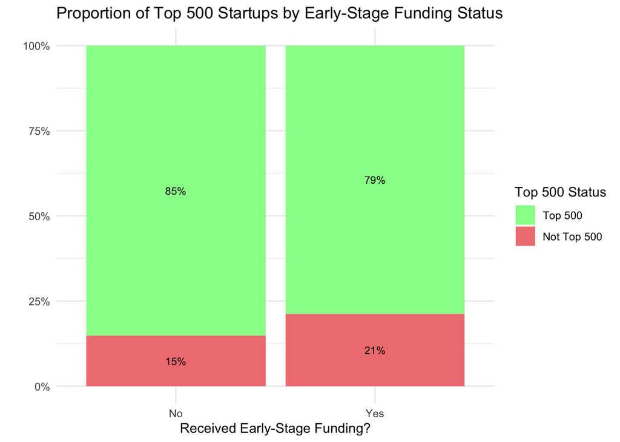

```r
startup_data$early_stage_funding <- factor(if_else(startup_data$has_angel == 1 | startup_data$has_roundA == 1, "Yes", "No"),
                                           levels = c('No', 'Yes'))

startup_data$is_top500_factor <- factor(startup_data$is_top500,
                                        levels = c(TRUE, FALSE),
                                        labels = c("Top 500", "Not Top 500"))

count_rates <- startup_data |>
  count(early_stage_funding, is_top500_factor) |>
  group_by(early_stage_funding) |>
  mutate(prop = n / sum(n)) |>
  ungroup()

ggplot(count_rates, aes(x = early_stage_funding, y = prop, fill = is_top500_factor)) +
  geom_bar(stat = "identity") +
  scale_y_continuous(labels = percent_format()) +
  scale_fill_manual(values = c("Top 500" = "palegreen", "Not Top 500" = "lightcoral")) +
  labs(
    title = "Proportion of Top 500 Startups by Early-Stage Funding Status",
    x = "Received Early-Stage Funding?",
    y = "",
    fill = "Top 500 Status"
  ) +
  theme_minimal() +
  geom_text(aes(label = scales::percent(prop, accuracy = 1)),
            position = position_stack(vjust = 0.5),
            size = 3,
            color = "black")
```

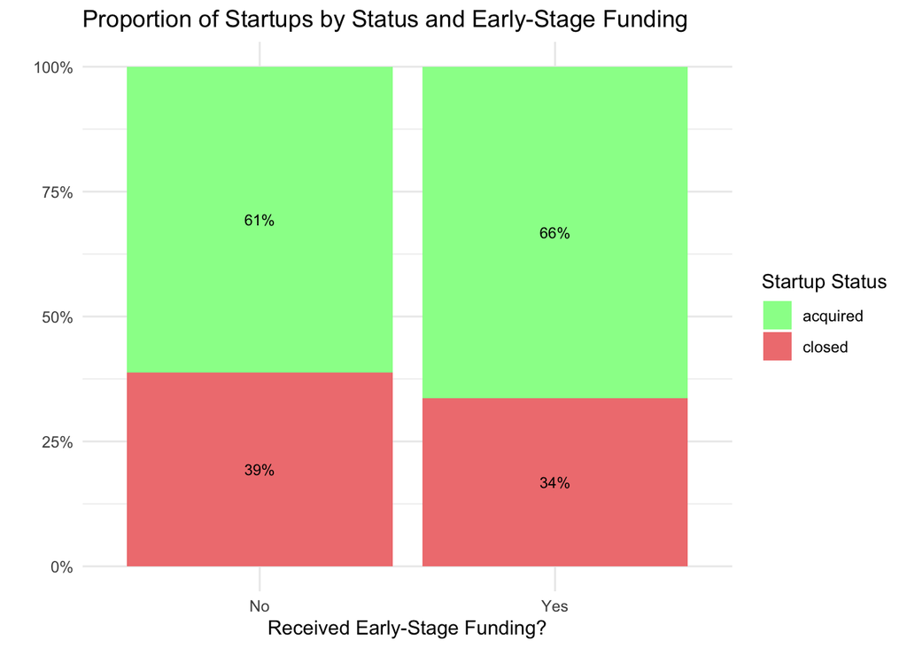

```r
startup_data$early_stage_funding <- factor(if_else(startup_data$has_angel == 1 | startup_data$has_roundA == 1, "Yes", "No"),
                                           levels = c('No', 'Yes'))

startup_data$status_factor <- factor(startup_data$status, levels = c('acquired', 'closed'))

count_rates <- startup_data |>
  count(early_stage_funding, status_factor) |>
  group_by(early_stage_funding) |>
  mutate(prop = n / sum(n)) |>
  ungroup()

ggplot(count_rates, aes(x = early_stage_funding, y = prop, fill = status_factor)) +
  geom_bar(stat = "identity") +
  scale_y_continuous(labels = percent_format()) +
  scale_fill_manual(values = c("acquired" = "palegreen", "closed" = "lightcoral")) +
  labs(
    title = "Proportion of Startups by Status and Early-Stage Funding",
    x = "Received Early-Stage Funding?",
    y = "",
    fill = "Startup Status"
  ) +
  theme_minimal() +
  geom_text(aes(label = scales::percent(prop, accuracy = 1)),
            position = position_stack(vjust = 0.5),
            size = 3,
            color = "black")
```

I’m using `glm()` because it is more fitting for our data than `lm()`, where we have binary outcome variables. With `glm()` we can use the “binomial” option. You may read more about it [here](https://sscc.wisc.edu/sscc/pubs/glm-r/#glm-families).

### Regression Function

```r
run_logistic_regression <- function(data, response, predictor) {
  formula <- as.formula(paste(response, "~", predictor))
  model <- glm(formula, data = data, family = "binomial", maxit = 1000)
  return(summary(model))
}
```

#### Example Usage

```r
startup_data$status_factor <- ifelse(startup_data$status == "acquired", 1, 0)

logistic_model_angel <- run_logistic_regression(startup_data, "status_factor", "has_angel")

logistic_model_series_a <- run_logistic_regression(startup_data, "status_factor", "has_roundA")

print(logistic_model_angel)
```

```
Call:
glm(formula = formula, family = "binomial", data = data, maxit = 1000)

Coefficients:
            Estimate Std. Error z value Pr(>|z|)
(Intercept)   0.6953     0.0809   8.594   <2e-16 ***
has_angel    -0.3428     0.1552  -2.208   0.0272 *
---
Signif. codes:  0 '***' 0.001 '**' 0.01 '*' 0.05 '.' 0.1 ' ' 1

(Dispersion parameter for binomial family taken to be 1)

    Null deviance: 1198.8  on 922  degrees of freedom
Residual deviance: 1194.0  on 921  degrees of freedom
AIC: 1198

Number of Fisher Scoring iterations: 4
```

```r
print(logistic_model_series_a)
```

```
Call:
glm(formula = formula, family = "binomial", data = data, maxit = 1000)

Coefficients:
            Estimate Std. Error z value Pr(>|z|)
(Intercept)  0.23008    0.09449   2.435   0.0149 *
has_roundA   0.78224    0.14084   5.554 2.79e-08 ***
---
Signif. codes:  0 '***' 0.001 '**' 0.01 '*' 0.05 '.' 0.1 ' ' 1

(Dispersion parameter for binomial family taken to be 1)

    Null deviance: 1198.8  on 922  degrees of freedom
Residual deviance: 1167.2  on 921  degrees of freedom
AIC: 1171.2

Number of Fisher Scoring iterations: 4
```

## Early Stage Funding Regression with “Success” Metrics

### Success Metric - Top 500

```r
startup_data$is_top500_factor <- as.numeric(startup_data$is_top500)

startup_data$early_stage_funding <- ifelse(startup_data$early_stage_funding == "Yes", 1, 0)
run_logistic_regression(startup_data, "is_top500_factor", "early_stage_funding")
```

```
Call:
glm(formula = formula, family = "binomial", data = data, maxit = 1000)

Coefficients:
                    Estimate Std. Error z value Pr(>|z|)
(Intercept)           1.7473     0.1598  10.936   <2e-16 ***
early_stage_funding  -0.4348     0.1879  -2.315   0.0206 *
---
Signif. codes:  0 '***' 0.001 '**' 0.01 '*' 0.05 '.' 0.1 ' ' 1

(Dispersion parameter for binomial family taken to be 1)

    Null deviance: 899.39  on 922  degrees of freedom
Residual deviance: 893.80  on 921  degrees of freedom
AIC: 897.8

Number of Fisher Scoring iterations: 4
```

In this logistic regression analysis, we can see that the coefficient for `early_stage_funding` is negative, suggesting that early-stage funding may decrease the likelihood of being in the top 500 startups compared to not. The results are statistically significant, with a p-value of 0.0206. However the effect size is relatively small and one should note that many other factors play a role in affecting startup success.

### Success Metric - Acquired

```r
run_logistic_regression(startup_data, "status_factor", "early_stage_funding")
```

```
Call:
glm(formula = formula, family = "binomial", data = data, maxit = 1000)

Coefficients:
                    Estimate Std. Error z value Pr(>|z|)
(Intercept)           0.4595     0.1166   3.941 8.12e-05 ***
early_stage_funding   0.2214     0.1446   1.531    0.126
---
Signif. codes:  0 '***' 0.001 '**' 0.01 '*' 0.05 '.' 0.1 ' ' 1

(Dispersion parameter for binomial family taken to be 1)

    Null deviance: 1198.8  on 922  degrees of freedom
Residual deviance: 1196.5  on 921  degrees of freedom
AIC: 1200.5

Number of Fisher Scoring iterations: 4
```

In this logistic regression analysis, we can see that the coefficient for `early_stage_funding` is positive, suggesting that early-stage funding may increase the likelihood of a startup being acquired. However the results are not statistically significant, with a p-value of 0.126.

# Conclusion